# Regression problem

**By: Thu Nguyen**

Note: This is the outcome of my coursework project in the Machine Learning Class.

# 1. Introduction

In this project, I will build and optimise (fine-tune) a regression model to predict the popularity of songs. Features of each song include "title", "artist", "top genre", "year", "bpm", "nrgy", "dnce", "dB", "live", "val", "dur", "cous", "spch". The ouput (predicted) value is the popularity of songs which is stored in column named "pop". The data has 3 non-numeric attributes, Id column, and 11 numeric attributes as seen in the picture below.

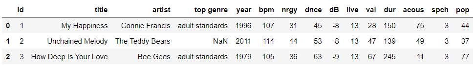

To build the final regression model, following steps were conducted:

**1 - Data exploration**

- In this step, besides detecting missing data, and outliers, I tried to analyze object features to see if one hot encoding could be used to transform non-numeric features into numeric data, which can be useful for regression modeling.

**2 - Data visualisation**

- In this step, I tried to visualise and define potential linear or non-linear relationships between "pop" and other features. I combined scatter plots and regression lines with different degrees, whereby I discovered two variables that could have a non-linear relationship with pop.

**3 - Data preparation**

- The data preparation step has been done with standard steps including **cleaning data**, **adding necessary variables**, and **scaling data**. Due to the training dataset is small, before removing outliers, I compared the performance of the trained models with the cleaned dataset and the unclean dataset to ensure that cleaning is necessary. Data cleaning has been proven effective. However, in this notebook, I show only the works related to the clean data.

**4 - Build and Fine-tune the best regression model**

- Finally, when the data was ready, different regression models including **LinearRegression, LinearSVR, DecisionTreeRegressor** and **RandomForestRegressor** are built. In addition, I also used two **ensemble learning** techniques **(Soft voting, Ada boosting)** to improve model scores. The model with **minimum RMSE** is chosen as the best model. Beside, I also tried the **Gradient Boosting** and **stacking** methods but the model's improvement was not found. Therefore, the Gradient Boosting and stacking methods are not included in this notebook.

The detailed explaination will be covered in the description of each code cell.

# 2. General setup

```python
# Python ≥3.5 is required
import sys
assert sys.version_info >= (3, 5)

# Scikit-Learn ≥0.20 is required
import sklearn
assert sklearn.__version__ >= "0.20"

# Common imports
import numpy as np
import pandas as pd
import os
import seaborn as sns

# To plot pretty figures
%matplotlib inline
import matplotlib as mpl
import matplotlib.pyplot as plt
mpl.rc('axes', labelsize=14)
mpl.rc('xtick', labelsize=12)
mpl.rc('ytick', labelsize=12)
```

# 3. Import data & exploring data

Download the data from a local .csv file, save it in a Pandas DataFrame, take a quick look at the first few line of the training dataset.

```python
df = pd.read_csv('CS98XRegression_Train.csv')
print('Training data shape: ',df.shape)
df = df.reset_index(drop=True)
df.head(3)
```

```
Training data shape:  (407, 15)
```

|  | Id | title | artist | top genre | year | bpm | nrgy | dnce | dB | live | val | dur | acous | spch | pop |
| --- | --- | --- | --- | --- | --- | --- | --- | --- | --- | --- | --- | --- | --- | --- | --- |
| 0 | 71 | Take Me Home Country Roads | John Denver | adult standards | 1971 | 82 | 40 | 46 | -9 | 12 | 63 | 190 | 76 | 3 | 70 |
| 1 | 182 | Locomotive | Thelonious Monk | bebop | 1967 | 112 | 44 | 67 | -11 | 13 | 70 | 400 | 78 | 4 | 46 |
| 2 | 411 | Fly Me To The Moon (In Other Words) | Frank Sinatra | adult standards | 1962 | 119 | 26 | 67 | -14 | 6 | 37 | 147 | 45 | 5 | 76 |

This dataset contain 15 columns and 407 instances. There are 3 non-numeric attributes, Id column, and 11 numeric attributes.

Due to year has meaning of timeline, so we convert it to age which has quantitative meaning and could be more helpful for regression problem.

```python
from datetime import date
today = date.today()
## add column "age" to data frame
df['age'] = today.year - df['year']
## drop column "year"
df = df.drop('year', axis=1)
df.head(3)
```

|  | Id | title | artist | top genre | bpm | nrgy | dnce | dB | live | val | dur | acous | spch | pop | age |
| --- | --- | --- | --- | --- | --- | --- | --- | --- | --- | --- | --- | --- | --- | --- | --- |
| 0 | 71 | Take Me Home Country Roads | John Denver | adult standards | 82 | 40 | 46 | -9 | 12 | 63 | 190 | 76 | 3 | 70 | 51 |
| 1 | 182 | Locomotive | Thelonious Monk | bebop | 112 | 44 | 67 | -11 | 13 | 70 | 400 | 78 | 4 | 46 | 55 |
| 2 | 411 | Fly Me To The Moon (In Other Words) | Frank Sinatra | adult standards | 119 | 26 | 67 | -14 | 6 | 37 | 147 | 45 | 5 | 76 | 60 |

Check null values. From the command below, I can see that the data has 10 NAN values in cloumn "top genre". I will due with this situation in step 5. Preparing data.

```python
df.isnull().sum()
```

```
Id            0
title         0
artist        0
top genre    10
bpm           0
nrgy          0
dnce          0
dB            0
live          0
val           0
dur           0
acous         0
spch          0
pop           0
age           0
dtype: int64
```

Next step, I investigate three non-numeric attributes to see how I can deal with them.

```python
df['title'].value_counts()
```

```
Please Mr. Postman                             2
Take Good Care Of My Baby - 1990 Remastered    2
Take Me Home Country Roads                     1
Something                                      1
Sunshine Reggae                                1
                                              ..
Bennie And The Jets - Remastered 2014          1
Dilemma                                        1
Numb                                           1
Waterloo                                       1
Pictures of Matchstick Men - Mono Version      1
Name: title, Length: 405, dtype: int64
```

```python
artist_count=df['artist'].value_counts()
artist_count
```

```
Elton John                   9
Queen                        7
The Beatles                  6
Rihanna                      5
Mariah Carey                 5
                            ..
Cream                        1
UFO                          1
Carpenters                   1
Artful Dodger                1
Captain Hollywood Project    1
Name: artist, Length: 317, dtype: int64
```

```python
df['top genre'].value_counts()
```

```
album rock            63
adult standards       62
dance pop             53
glam rock             16
brill building pop    14
                      ..
acoustic blues         1
british comedy         1
hi-nrg                 1
neo mellow             1
australian rock        1
Name: top genre, Length: 81, dtype: int64
```

As you can see, there are 81 different categories in 'top genre' column, 317 different artists in the 'artist' column, and 405 titles in the 'title' column. If I use **OneHotEncoder** to convert these columns to numerical (binary) data, I will have to many columns. Meanwhile, the dataframe has only 407 instances.

On the other hand, I do not want to use **ordinal_encoder** since it may impose some un-wanted relationships between categories.

Therefore, I will not use these three columns for building regression models. As a result, 10 NAN values in 'top genre' column will not cause any issue since this column will be excluded.

Moreover, there are two titles: "Take Good Care Of My Baby - 1990 Remastered" and "Please Mr. Postman" that are repeated twice in the dataset. We will try to deal with this issue in the prepare data section.

# 4. Data visuallisation

## 4.1. Distribution of data

First, I will plot histogram for numeric attributes to see the **distribution of training data**.

As shown in the picture below, except "dnce" feature that has nearly **normal distribution**, all other features have **skew distribution**.

- "dnce": close to **normal distribution**
- "bpm", "dur", "age": **positive skew distribution**
- "live", "acous", "spch": extreme **positive skew distribution** with very **long tail**
- "nrgy", "dB", "val": **negative skew distribution**

Moreover, the distribution of the data suggest some potential outliers that need to be removed. This work will be done in Section 5. Preparing data

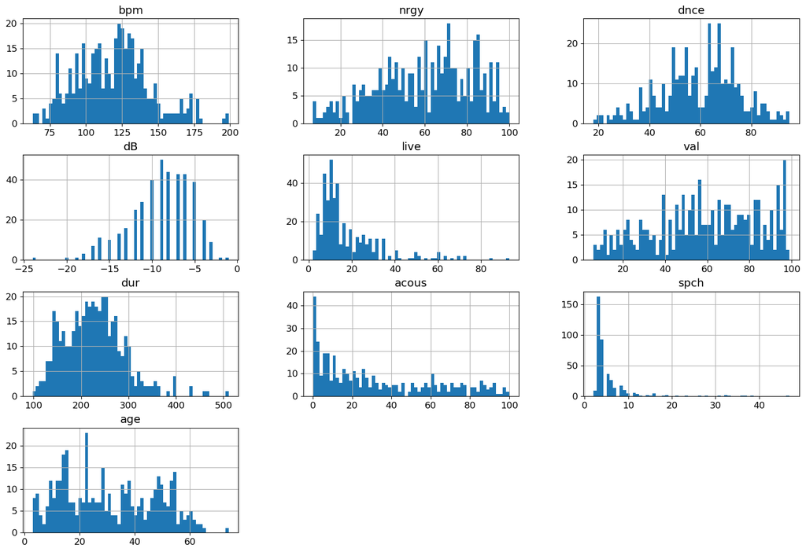

```python
cols = ['bpm','nrgy','dnce','dB','live','val','dur','acous','spch','age']
df[cols].hist(bins=60, figsize=(18,12))
plt.show()
```

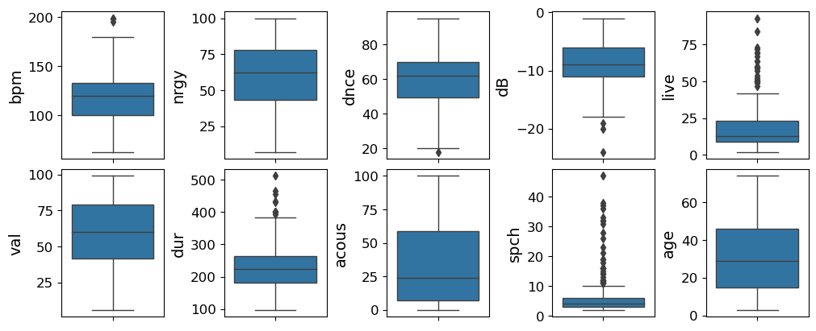

```python
plt.rc('font', size = 12)
fig = plt.figure(figsize=(10, 4),constrained_layout=True)
fig.tight_layout()

for i in range(len(cols)):
    plt.subplot(2,5,i+1)
    sns.boxplot(y=df[cols[i]], linewidth=1)
    plt.ylabel(cols[i])
```

## 4.2. Plot "pop" vs other features to observe potential linear/non-linear relations

```python
## Calculate correlation coefficients.
corr_matrix = df.corr()
corr_matrix["pop"].sort_values(ascending=False)
```

```
pop      1.000000
dur      0.344827
dB       0.322625
nrgy     0.287566
dnce     0.267827
spch     0.125772
Id       0.084509
age      0.070699
bpm      0.054083
val     -0.002459
live    -0.045419
acous   -0.446367
Name: pop, dtype: float64
```

In this step, I will plot scatter graphs and regression lines for 'pop' versus each individual feature (except feature 'val', since 'val' has very low correletation with 'pop'). In fact, I tried many times for both linear and non-linear assumptions with different degrees. These plots below are the best options.

```python
def plot_pop_vs_others(df, col_name, relation_degree, i):
    df2 = df.copy()
    df2 = df2.sort_values(by=[col_name])

    Xplot = df2[col_name]

    plt.subplot(3,3,i+1)
    z = np.polyfit(Xplot, df2['pop'], relation_degree)
    p = np.poly1d(z)
    plt.scatter(Xplot, df2['pop'], s=10)
    plt.plot(Xplot, p(Xplot), c='r', ls='-')
```

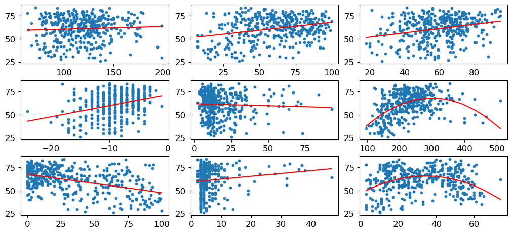

```python
plt.rc('font', size = 12)
fig = plt.figure(figsize=(10, 4.5),constrained_layout=True)
fig.tight_layout()

cols2 = ['bpm','nrgy','dnce','dB','live','dur','acous','spch','age']
for i in range(len(cols2)):
    col_name = cols2[i]
    if (col_name=='dur') | (col_name=='age'):
        relation_degree = 2
    else:
        relation_degree = 1

    plot_pop_vs_others(df, col_name, relation_degree, i)
```

Base on the correlation coefficients and plots, I can see that "dur" & "age" may have non-linear relations with "pop". The other attributes may have the potential linear relationships with "pop".

# 5. Preparing data

## 5.1. Clean data

### a) Clean repeated data

In the part of investigating 'title' column in section 3, I can see two songs repeated, which are 'Take Good Care Of My Baby - 1990 Remastered' and 'Please Mr. Postman'. We extract them for more detail.

```python
df[df["title"]=='Take Good Care Of My Baby - 1990 Remastered']
```

|  | Id | title | artist | top genre | bpm | nrgy | dnce | dB | live | val | dur | acous | spch | pop | age |
| --- | --- | --- | --- | --- | --- | --- | --- | --- | --- | --- | --- | --- | --- | --- | --- |
| 30 | 43 | Take Good Care Of My Baby - 1990 Remastered | Bobby Vee | adult standards | 82 | 43 | 49 | -12 | 12 | 66 | 151 | 70 | 6 | 60 | 11 |
| 38 | 47 | Take Good Care Of My Baby - 1990 Remastered | Bobby Vee | adult standards | 82 | 43 | 49 | -12 | 12 | 66 | 151 | 70 | 6 | 60 | 11 |

```python
df[df["title"]=='Please Mr. Postman']
```

|  | Id | title | artist | top genre | bpm | nrgy | dnce | dB | live | val | dur | acous | spch | pop | age |
| --- | --- | --- | --- | --- | --- | --- | --- | --- | --- | --- | --- | --- | --- | --- | --- |
| 149 | 178 | Please Mr. Postman | Carpenters | adult standards | 133 | 55 | 66 | -12 | 24 | 96 | 173 | 14 | 3 | 62 | 47 |
| 226 | 281 | Please Mr. Postman | The Marvelettes | brill building pop | 122 | 78 | 79 | -5 | 18 | 97 | 148 | 73 | 3 | 68 | 61 |

Since the data in rows 30 and 38 are identical, I will remove one of them. On the other hand, except from the song title, all other features in rows 149 and 226 are different. They may be two different versions of the song. Therefore, I can consider them as two different instances and will keep both of them.

```python
df = df.drop(38)
df[df["title"]=='Take Good Care Of My Baby - 1990 Remastered']
```

|  | Id | title | artist | top genre | bpm | nrgy | dnce | dB | live | val | dur | acous | spch | pop | age |
| --- | --- | --- | --- | --- | --- | --- | --- | --- | --- | --- | --- | --- | --- | --- | --- |
| 30 | 43 | Take Good Care Of My Baby - 1990 Remastered | Bobby Vee | adult standards | 82 | 43 | 49 | -12 | 12 | 66 | 151 | 70 | 6 | 60 | 11 |

### b) Drop un-used columns

The 'Id', 'title', 'artist', 'top genre' columns will not be used. Therefore, they are excluded from the dataset as follows:

```python
df = df.drop(['Id', 'title', 'artist', 'top genre'], axis=1)
df.head(3)
```

|  | bpm | nrgy | dnce | dB | live | val | dur | acous | spch | pop | age |
| --- | --- | --- | --- | --- | --- | --- | --- | --- | --- | --- | --- |
| 0 | 82 | 40 | 46 | -9 | 12 | 63 | 190 | 76 | 3 | 70 | 51 |
| 1 | 112 | 44 | 67 | -11 | 13 | 70 | 400 | 78 | 4 | 46 | 55 |
| 2 | 119 | 26 | 67 | -14 | 6 | 37 | 147 | 45 | 5 | 76 | 60 |

### c) Remove outliers manually

As seen in Section 4.1, there are some potential outliers in the dataset. I will remove few data points that are really exceptional cases.

```python
print("Data shape before manually removing outliers: ", df.shape)

df = df[df['dur']< 500]
df = df[(df['spch']< 40)]
df = df[df['dB'] > -22]
df = df[df['live'] < 80]

print("Data shape after manually removing outliers: ", df.shape)
```

```
Data shape before manually removing outliers:  (406, 11)
Data shape after manually removing outliers:  (401, 11)
```

### d) Remove outliers by using DBSCAN clustering

In addition to removing manually base on the box plot in the previous step, I will use clustering technique to detect anormal data points which can be considered as outliers which need to be removed. As I can see in the plots in Section 4.1 and 4.2, the data distributions are not really spherical. Therefore, **DBSCAN clustering** is chosen.

The value of parameter "eps" in each clustering will be adjusted according to the density of the scatter plots observed in Section 4. In general, I use a very large value for "eps" to avoid removal of too many data points.

```python
from sklearn.cluster import DBSCAN

print("Data shape before removing outliers using DBSCAN clustering: ", df.shape)

## clustering for a sub-dataframe with only two columns: 'pop' and 'acous'
dbscan = DBSCAN(eps=9, min_samples=5)
dbscan.fit(df[['acous', 'pop']])
# dbscan.labels_
df = df.loc[dbscan.labels_!=-1]

## clustering for a sub-dataframe with only two columns: 'pop' and 'dur'
dbscan = DBSCAN(eps=15, min_samples=5)
dbscan.fit(df[['dur', 'pop']])
# dbscan.labels_
df = df.loc[dbscan.labels_!=-1]

## clustering for a sub-dataframe with only two columns: 'pop' and 'nrgy'
dbscan = DBSCAN(eps=10, min_samples=5)
dbscan.fit(df[['nrgy', 'pop']])
# dbscan.labels_
df = df.loc[dbscan.labels_!=-1]

## clustering for a sub-dataframe with only two columns: 'pop' and 'dnce'
dbscan = DBSCAN(eps=10, min_samples=5)
dbscan.fit(df[['dnce', 'pop']])
# dbscan.labels_
df = df.loc[dbscan.labels_!=-1]

## clustering for a sub-dataframe with only two columns: 'pop' and 'age'
dbscan = DBSCAN(eps=10, min_samples=5)
dbscan.fit(df[['age', 'pop']])
# dbscan.labels_
df = df.loc[dbscan.labels_!=-1]

df = df.reset_index(drop=True)
print("Data shape after removing outliers using DBSCAN clustering: ", df.shape)
```

```
Data shape before removing outliers using DBSCAN clustering:  (401, 11)
Data shape after removing outliers using DBSCAN clustering:  (380, 11)
```

```python
corr_matrix = df.corr()
corr_matrix["pop"].sort_values(ascending=False)
```

```
pop      1.000000
dur      0.507762
dB       0.341964
dnce     0.324732
nrgy     0.323928
spch     0.149681
age      0.065953
bpm      0.035840
val      0.010340
live    -0.049488
acous   -0.471727
Name: pop, dtype: float64
```

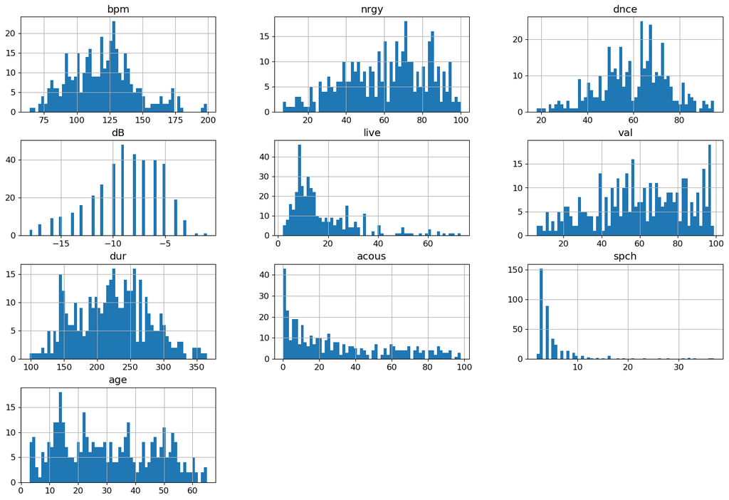

```python
cols = ['bpm','nrgy','dnce','dB','live','val','dur','acous','spch','age']
df[cols].hist(bins=60, figsize=(18,12))
plt.show()
```

## 5.2. Adding features: age^2 and dur^2

Since the potential quadratic relations between 'pop' versus 'age' and 'dur' are observed in section 4.2, I will add two additional columns for age^2 and dur^2 into the dataset as follows:

```python
df['age2']=df['age']**2
df['dur2']=df['dur']**2
df.head(3)
```

|  | bpm | nrgy | dnce | dB | live | val | dur | acous | spch | pop | age | age2 | dur2 |
| --- | --- | --- | --- | --- | --- | --- | --- | --- | --- | --- | --- | --- | --- |
| 0 | 82 | 40 | 46 | -9 | 12 | 63 | 190 | 76 | 3 | 70 | 51 | 2601 | 36100 |
| 1 | 119 | 26 | 67 | -14 | 6 | 37 | 147 | 45 | 5 | 76 | 60 | 3600 | 21609 |
| 2 | 71 | 40 | 41 | -10 | 30 | 22 | 354 | 27 | 5 | 84 | 47 | 2209 | 125316 |

## 5.3. Feature scaling

Based on the correlation scores shown in Section 5.1, I decided to exclude 'val' feature from the process of building models. A list of features that will be included in the training process are defined in 'features' variable as below. In fact, this is the best list of features that I found after many trial combinations of features.

```python
features = ['dur', 'dur2', 'nrgy', 'dB', 'dnce', 'spch', 'bpm', 'age','age2', 'live', 'acous']
from sklearn.preprocessing import StandardScaler
autoscaler = StandardScaler()
y = df['pop']

X_train = autoscaler.fit_transform(df[features])
```

## 6. Training models

```python
from sklearn.linear_model import LinearRegression
from sklearn.svm import LinearSVR
from sklearn.tree import DecisionTreeRegressor
from sklearn.ensemble import RandomForestRegressor

from sklearn.model_selection import GridSearchCV
from sklearn.model_selection import cross_val_score

from sklearn.model_selection import train_test_split
from sklearn.metrics import mean_squared_error

## AdaBoost
from sklearn.ensemble import AdaBoostRegressor
## Gradient Boosting
# from sklearn.ensemble import GradientBoostingRegressor
```

## 6.1. Train and Fine-Tune Individual Model

First, I will try four different regression models including: **LinearRegression, LinearSVR, DecisionTreeRegressor** and **RandomForestRegressor**. The best model will be determined by using following steps:

During training, the **cross validation** technique with **cv=5** is used to **split data into 5 folds**. The best paramters will be used for training the optimised model.

### 6.1.1. Linear Regression

```python
lin_reg = LinearRegression()

scores = cross_val_score(lin_reg, X_train, y,scoring="neg_mean_squared_error", cv=5)
lin_reg_rmse_scores = np.sqrt(-scores)
print(lin_reg_rmse_scores.mean())

lin_reg.fit(X_train, y)
lin_reg.coef_
```

```
9.790074256674282
```

```
array([ 21.52361603, -17.3437061 ,  -1.77409255,   3.63869028,
         2.05257114,   0.38204466,  -0.0681137 ,  10.00147207,
        -7.64768922,  -0.36319734,  -2.30792349])
```

### 6.1.2. Fine-Tune Support Vector Regression Model

The tolerance 'tol' of the LinearSVR model is set equal to 1e-5, and a gridsearch for 'loss' parameter is conducted.

```python
svm_reg = LinearSVR(tol=1e-5)

param_grid = {'loss': ['epsilon_insensitive', 'squared_epsilon_insensitive']}

grid_search = GridSearchCV(svm_reg, param_grid, cv=5, scoring='neg_mean_squared_error',return_train_score=True)
grid_search.fit(X_train, y)
best_para = grid_search.best_params_

## optimised SVR model:
svm_reg = LinearSVR(tol=1e-5, loss = best_para['loss'])

scores = cross_val_score(svm_reg, X_train, y, scoring="neg_mean_squared_error", cv=5)
svm_reg_rmse_scores = np.sqrt(-scores)
print(svm_reg_rmse_scores.mean())

svm_reg.fit(X_train, y)
```

```
9.78836832931138
```

```
LinearSVR(loss='squared_epsilon_insensitive', tol=1e-05)
```

### 6.1.3. Fine-Tune Decision Tree Regression Model

Two parameters: 'max_features' and 'max_depth' are used for the gridsearch.

```python
tree_reg = DecisionTreeRegressor()

param_grid = {'max_features': ['auto', 'sqrt', 'log2'], 'max_depth': [2, 4, 6, 8, 10,12,14,16,18,20]}

grid_search = GridSearchCV(tree_reg, param_grid, cv=5, scoring='neg_mean_squared_error',return_train_score=True)
grid_search.fit(X_train, y)
best_para = grid_search.best_params_


## optimised DecisionTreeRegressor model:
tree_reg = DecisionTreeRegressor(max_depth=best_para['max_depth'], max_features=best_para['max_features'])

scores = cross_val_score(tree_reg, X_train, y, scoring="neg_mean_squared_error", cv=5)
tree_reg_rmse_scores = np.sqrt(-scores)
print(tree_reg_rmse_scores.mean())

tree_reg.fit(X_train, y)
```

```
10.899752207551439
```

```
DecisionTreeRegressor(max_depth=2, max_features='auto')
```

### 6.1.4. Fine-Tune Random Forest Model

Three parameters: 'n_estimators', 'max_features' and 'bootstrap' are used for the gridsearch.

```python
forest_reg = RandomForestRegressor()

param_grid = {'n_estimators': [10, 20, 30, 40, 50, 60, 70, 80, 90, 100], 'max_features': ['auto', 'sqrt', 'log2'],
              'bootstrap': [True, False]}

grid_search = GridSearchCV(forest_reg, param_grid, cv=5, scoring='neg_mean_squared_error',return_train_score=True)
grid_search.fit(X_train, y)
best_para = grid_search.best_params_

## Optimised Random Forest model:
forest_reg = RandomForestRegressor(n_estimators=best_para['n_estimators'], bootstrap=best_para['bootstrap'],
                                   max_features=best_para['max_features'])

scores = cross_val_score(forest_reg, X_train, y,scoring="neg_mean_squared_error", cv=5)
forest_reg_rmse_scores = np.sqrt(-scores)
print(forest_reg_rmse_scores.mean())

forest_reg.fit(X_train, y)
```

```
9.989025799705228
```

```
RandomForestRegressor(max_features='log2')
```

## 6.2. Ensemble Learning

As the next step, we will use soft voting and Ada boosting methods to improve the models' performances.

### 6.2.1. Soft voting for the best individual models

By trying different model combinations, we found that soft-voting model of three individual models including 'lin_reg', 'forest_reg' and 'svm_reg' give the higher score than the soft-voting model of all four idividual models. It is because the Decision Tree Regression Model has very low score compared to the others. Therefore, as shown in section below, we only conduct soft voting for three models:

```python
from sklearn.ensemble import VotingRegressor

soft_voting = VotingRegressor(estimators=[('lr', lin_reg), ('forest', forest_reg), ('svm', svm_reg)])

scores = cross_val_score(soft_voting, X_train, y, scoring="neg_mean_squared_error", cv=5)
soft_voting_rmse_scores = np.sqrt(-scores)
print(soft_voting_rmse_scores.mean())

soft_voting.fit(X_train, y)
```

```
9.637025631362913
```

```
VotingRegressor(estimators=[('lr', LinearRegression()),
                            ('forest',
                             RandomForestRegressor(max_features='log2')),
                            ('svm',
                             LinearSVR(loss='squared_epsilon_insensitive',
                                       tol=1e-05))])
```

### 6.2.2. Ada boosting model

We try to use Ada boosting for the achieved 'soft_voting' model. It is noted that the Ada bossting for each individual model was also tried. However, the performances of those boosting models were not good. On the other hand, sometimes, we did capture slight improvemements when we try Ada boosting for the achieved 'soft_voting' model.

```python
# Ada boosting
from sklearn.ensemble import AdaBoostRegressor

adb_rgr = AdaBoostRegressor(soft_voting, n_estimators=1000, learning_rate=0.5)

scores = cross_val_score(adb_rgr, X_train, y, scoring="neg_mean_squared_error", cv=5)
adb_rgr_rmse_scores = np.sqrt(-scores)
print(adb_rgr_rmse_scores.mean())

adb_rgr.fit(X_train, y)
```

```
9.700680797791648
```

```
AdaBoostRegressor(base_estimator=VotingRegressor(estimators=[('lr',
                                                              LinearRegression()),
                                                             ('forest',
                                                              RandomForestRegressor(max_features='log2')),
                                                             ('svm',
                                                              LinearSVR(loss='squared_epsilon_insensitive',
                                                                        tol=1e-05))]),
                  learning_rate=0.5, n_estimators=1000)
```

# 7. Predict test data & choose final model

Based on the RMSE values for models trained in Section 6, I can summary these values in a dataframe as below. As you can see, ML model built using **Soft Voting** technique gives smallest RMSE value.

```python
model_names = ['Linear Regression', 'Support Vector Regression', 'Decision Tree Regression',
               'Random Forest Regression', 'Soft Voting', 'Ada boosting']
model_RMSE = [lin_reg_rmse_scores.mean(), svm_reg_rmse_scores.mean(), tree_reg_rmse_scores.mean(),
             forest_reg_rmse_scores.mean(), soft_voting_rmse_scores.mean(), adb_rgr_rmse_scores.mean()]
df_models = pd.DataFrame(list(zip(model_names, model_RMSE)), columns =['model', 'train_mean_RMSE'])
df_models = df_models.sort_values(by=['train_mean_RMSE'])
df_models
```

|  | model | train_mean_RMSE |
| --- | --- | --- |
| 4 | Soft Voting | 9.637026 |
| 5 | Ada boosting | 9.700681 |
| 1 | Support Vector Regression | 9.788368 |
| 0 | Linear Regression | 9.790074 |
| 3 | Random Forest Regression | 9.989026 |
| 2 | Decision Tree Regression | 10.899752 |

Now, let's use these model to make predictions for the test set.

First, I need to conduct the same operations that I did for training set. These operations include converting year to age, removing 'year', 'title', 'artist', 'top genre' columns, and adding 'age2' and 'dur2' columns as belows:

```python
df_test = pd.read_csv('CS98XRegression_Test.csv')
y_test = df_test['pop']

today = date.today()
df_test['age'] = today.year - df_test['year']

df_test = df_test.drop(['year', 'title', 'artist', 'top genre'], axis=1)
df_test['age2'] = df_test['age']**2
df_test['dur2'] = df_test['dur']**2

X_test = autoscaler.fit_transform(df_test[features])
```

Now, let's make prediction:

```python
# Load the pickled model
pop_lin_reg = lin_reg.predict(X_test)
pop_svm_reg = svm_reg.predict(X_test)
pop_tree_reg = tree_reg.predict(X_test)
pop_forest_reg = forest_reg.predict(X_test)
pop_soft_voting = soft_voting.predict(X_test)
pop_adb_rgr = adb_rgr.predict(X_test)
```

```python
from sklearn.metrics import mean_squared_error

rms_lin_reg = mean_squared_error(y_test, pop_lin_reg, squared=False)
rms_svm_reg = mean_squared_error(y_test, pop_svm_reg, squared=False)
rms_tree_reg = mean_squared_error(y_test, pop_tree_reg, squared=False)
rms_forest_reg = mean_squared_error(y_test, pop_forest_reg, squared=False)
rms_soft_voting = mean_squared_error(y_test, pop_soft_voting, squared=False)
rms_adb_rgr = mean_squared_error(y_test, pop_adb_rgr, squared=False)

df_models['test_RMSE'] = [rms_soft_voting, rms_adb_rgr, rms_svm_reg, rms_lin_reg, rms_forest_reg, rms_tree_reg]
df_models
```

|  | model | train_mean_RMSE | test_RMSE |
| --- | --- | --- | --- |
| 4 | Soft Voting | 9.637026 | 10.496835 |
| 5 | Ada boosting | 9.700681 | 10.585293 |
| 1 | Support Vector Regression | 9.788368 | 10.517330 |
| 0 | Linear Regression | 9.790074 | 10.446986 |
| 3 | Random Forest Regression | 9.989026 | 11.168908 |
| 2 | Decision Tree Regression | 10.899752 | 13.373365 |

```python
## save model
import pickle

filename = 'soft_voting.sav'
pickle.dump(soft_voting, open(filename, 'wb'))

## load model and make prediction
loaded_model = pickle.load(open(filename, 'rb'))

pop_predicted = loaded_model.predict(X_test[10:20,:])
print(pop_predicted.round())
```

```
[47. 68. 63. 58. 57. 47. 75. 56. 66. 69.]
```